# caret & recipes demo

Michael Levy michael.levy@healthcatalyst.com

2017-10-05

I’m thinking we should use caret. Why I’ve changed my thinking about this:

1. Taylor Miller used the term battle-tested to describe the methods we use, and that has been bouncing through my head all day. `caret` is battle-tested. It’s been around for a long time and has been through several refactors.
2. It does a lot of what we want to do. We can wrap this stuff instead of reinventing it, and therefore focus on our value proposition (which I see as lowering the burden to entry of ML via healthcare specific functionality and providing the simplest possible API to ML)
3. The author has made a helper package, [`recipes`](https://topepo.github.io/recipes/index.html) that would allow us to capture pre-processing steps like imputation and normalization and apply them identically in development and deployment.
4. caret is well liked by the community. I still think the documentation is sub-par, but the fact that smart, experienced people like it makes me think I never get over the caret-specific learning curve. Eduardo Arino de la Rubia, who gave the *R/Python is the best* talk Taylor posted, [said](https://www.youtube.com/watch?v=YmHyAHkjX_A) “This is probably a little extreme, but I believe caret is one of R’s genuine competitive advantages…”
5. It is extensible. So while it doesn’t have native support for xgb, [we can still use xgb in the caret framework](https://topepo.github.io/caret/using-your-own-model-in-train.html).
6. It will keep us on the rails of modern R modeling. Kuhn, the developer of caret, has Hadley working on the `recpies` helper package, which is a good signal.
7. It has a [ton of models](http://topepo.github.io/caret/available-models.html), any of which would be easy for us to add support for.

# Demo

This obviously doesn’t cover everything, but it shows how the packages work. I’ve comments to document what is `caret`, `recipes`, and `tidyverse` respectively.

Load packages and data and split into train and test sets:

```r
library(tidyverse)
library(recipes)
library(caret)
csvfile <- system.file("extdata", "HCRDiabetesClinical.csv", package = "healthcareai")
df <- read.csv(file = csvfile, header = TRUE, na.strings = c("NULL", "NA", ""))
# tidyverse:
df <- replace_na(df, list(ThirtyDayReadmitFLG = "N"))  # Fill in the outcome,
# Impute on the predictors later
# caret:
trainRows <- createDataPartition(df$ThirtyDayReadmitFLG, 1, .9)$Resample1
# tidyverse:
trainDF <- slice(df, trainRows)
testDF <- slice(df, -trainRows)
```

Define a “recipe” of data prep:

```r
# recipes:
# This defines the pipeline but doesn't manipulate the data
myRecipe <-
  trainDF %>%
  recipe(ThirtyDayReadmitFLG ~ SystolicBPNBR + LDLNBR + A1CNBR + GenderFLG) %>%
  step_knnimpute(all_predictors(), K = 3) %>% # Also has bagged trees imputation, and mean and mode
  step_center(all_numeric()) %>%
  step_scale(all_numeric()) %>%
  step_dummy(all_nominal(), -all_outcomes()) # Here, could just do step_dummy(GenderFLG)
myRecipe
```

```
Data Recipe

Inputs:

      role #variables
   outcome          1
 predictor          4

Steps:

3-nearest neighbor imputation for all_predictors()
Centering for all_numeric()
Scaling for all_numeric()
Dummy variables from all_nominal(), -all_outcomes()
```

Apply the recipe to the training data to create a model matrix

```r
# This does calculations needed to manipulate the data (e.g. determine impute values)
myRecipe <- prep(myRecipe)
```

```
step 1 knnimpute training
step 2 center training
step 3 scale training
step 4 dummy training
```

```r
# Now we can apply those transformations to any dataset (by default the one defined on,
# but also the deployment dataset)
modelMatrix <- bake(myRecipe)
head(modelMatrix)
```

| SystolicBPNBR | LDLNBR | A1CNBR | GenderFLG_M |
| --- | --- | --- | --- |
| 0.715523532 | 1.3927944 | -1.734660 | 1 |
| 0.156488919 | 1.8967912 | -1.044346 | 1 |
| 1.514144409 | -0.1987744 | -1.562081 | 1 |
| 1.554075453 | -0.4640358 | -1.648371 | 1 |
| 1.594006497 | -1.1006633 | -1.907239 | 1 |
| -0.003235257 | 0.4643793 | -1.044346 | 1 |

Define cross-validation details using random hyperparameter search. There is a lot of functionality on offer around hyperparameter tuning and model selection.

```r
# caret:
# define model-agnostic details for hyperparameter tuning
cvDetails <-
  trainControl(method = "cv",  # Can do repeat cv and bootstrapping just as easily
               number = 5,
               classProbs = TRUE,  # Choose an optimal threshold and make Y/N calls
               summaryFunction = twoClassSummary,  # Lots of options here
               search = "random"  # or grid or modest support for fancier methods
  )
```

Train a model and inspect

```r
rfFit <- train(x = modelMatrix,
               y = trainDF$ThirtyDayReadmitFLG,
               metric = "ROC",
               trControl = cvDetails,
               tuneLength = 5  # How many hyperparameter combos to try
               )
methods(class = class(rfFit))  # Lots of methods available for us. Eg:
```

```
 [1] confusionMatrix densityplot     fitted          ggplot          histogram       levels          plot            predict
 [9] predictors      print           residuals       stripplot       summary         update          varImp          xyplot
see '?methods' for accessing help and source code
```

```r
confusionMatrix(rfFit)
```

```
Cross-Validated (5 fold) Confusion Matrix

(entries are percentual average cell counts across resamples)

          Reference
Prediction    N    Y
         N 84.2 11.9
         Y  0.3  3.6

 Accuracy (average) : 0.8779
```

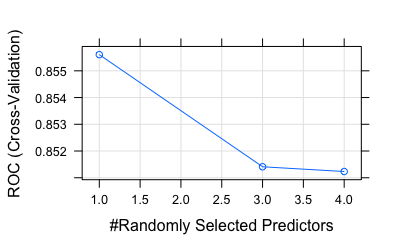

```r
plot(rfFit)
```

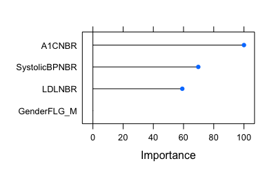

```r
varImp(rfFit) %>%
  plot()
```

Deployment can be as easy as:

```r
preds <-
  bake(myRecipe, newdata = testDF) %>%
  predict(rfFit, .)
# And inspect:
confusionMatrix(preds, testDF$ThirtyDayReadmitFLG)
```

```
Confusion Matrix and Statistics

          Reference
Prediction  N  Y
         N 83 12
         Y  1  3

               Accuracy : 0.8687
                 95% CI : (0.7859, 0.9282)
    No Information Rate : 0.8485
    P-Value [Acc > NIR] : 0.347249

                  Kappa : 0.2692
 Mcnemar's Test P-Value : 0.005546

            Sensitivity : 0.9881
            Specificity : 0.2000
         Pos Pred Value : 0.8737
         Neg Pred Value : 0.7500
             Prevalence : 0.8485
         Detection Rate : 0.8384
   Detection Prevalence : 0.9596
      Balanced Accuracy : 0.5940

       'Positive' Class : N
```